# Grid cell size 10m^2

David

11 April, 2021

Import libraries

```r
library(here)
library(raster)
library(sf)
library(tidyverse)
library(mgcv)
library(ctmcmove)
library(rgdal)
library(glue)
library(broom)
library(dotwhisker)
```

Read in data

```r
reefclass <- raster(here("data/Seabed Maps/geotiff/", "ChickenRock_Classification.tif"))
df<-read_csv(here("data/red.snapper.locations.csv"))
current_resolution<-params$resolution
current_resolution
```

```
## [1] 10
```

```r
cat(paste0("the current grid size being used is ", current_resolution, "  meters ^2"))
```

```
## the current grid size being used is 10  meters ^2
```

Raster values: - sand == 1 - low == 2 - medium == 3 - high == 4

Resize landcover data using parameter value. Take the most common values (the mode) from the original 1m cells to assign larger cells.

```r
ras<-aggregate(reefclass, fact=params$resolution, fun=modal)
```

Pull off coordinate reference system from landcover raster and transform snapper GPS data to match

```r
# pull off coordinate reference system from land cover raster layer
crs_ras<-crs(ras)

# convert snapper points to spatial object
df<-df %>% st_as_sf(coords = c("lon", "lat"), crs = 4326)

# transform points to crs of raster
df<-st_transform(df, crs=crs_ras)

# double check
st_crs(df)==st_crs(ras)
```

```
## [1] TRUE
```

Create a raster layer for the intercept in the eventual GLM model

```r
int<-ras
values(int)<-1

stack_rast<-stack(int, ras)
names(stack_rast)<-cbind(c("int", names(ras)))
```

Pull off coordinates from snapper gps layer to use later. (Converting to spatial sf object ‘sucks up’ the coordinate columns from the dataframe)

```r
df<-df %>%
  mutate(x=st_coordinates(.)[,1],
         y=st_coordinates(.)[,2])
```

Drop points that fall outside the extent of the landcover raster

```r
df$ras_value<-raster::extract(ras, df)
df<-df %>% drop_na(ras_value)
```

A little more housekeeping

```r
df<-df %>% arrange(num, datetime)
df<-df %>% rename(id=num) # one transmitter used on two fish, so num is the unique ID for each fish
```

Only use 3 fish for comparative purposes

```r
df<-df %>%
  filter(id==9|id==12|id==16)
```

Process data for CTMC

```r
ids<-as_factor(unique(df$id))
snapper_list<-list()

for(i in seq_along(ids)){
  tmp<-df %>% filter(id==ids[[i]])

  ## turn time into a numeric value (in days since Jan 1, 1970)
  t<-as.numeric(strptime(tmp$datetime, format="%Y-%m-%d %H:%M:%S"))/60/60/24

  ## get xy values for each time point
  xy<-tmp %>% dplyr::select(x,y)

  snapper_list[[i]]<-data.frame(t=t, x=xy$x, y=xy$y)
}
```

Convert from discrete-time continuous-space to continuous-time discrete space using landcover grid.

```r
n_snap<-length(snapper_list)
ctmc_list<-list()

for(i in 1:n_snap){
  ctmc_list[[i]]<-path2ctmc(xy = snapper_list[[i]][,-1],
                            t = as.numeric(snapper_list[[i]][,1]),
                            method="LinearInterp",
                            rast = stack_rast
                            )}
```

Convert CTMC path into poisson glm data

```r
glm_list<-list()

for(i in 1:n_snap){
  glm_list[[i]]<-ctmc2glm(ctmc_list[[i]],
                          stack.static = stack_rast,
                          stack.grad = ras)
}

str(glm_list[[1]])
```

```
## 'data.frame':    268142 obs. of  11 variables:
##  $ z                         : num  0 0 1 0 0 0 1 0 0 0 ...
##  $ int                       : num  1 1 1 1 1 1 1 1 1 1 ...
##  $ ChickenRock_Classification: num  4 4 4 4 4 4 4 4 4 4 ...
##  $ X.grad                    : num  -1.39e-17 1.39e-17 0.00 0.00 -1.39e-17 ...
##  $ crw                       : num  0 0 0 0 0 0 1 -1 0 0 ...
##  $ x.current                 : num  395689 395689 395689 395689 395689 ...
##  $ y.current                 : num  3831773 3831773 3831773 3831773 3831783 ...
##  $ x.adj                     : num  395679 395699 395689 395689 395679 ...
##  $ y.adj                     : num  3831773 3831773 3831783 3831763 3831783 ...
##  $ tau                       : num  0.0011 0.0011 0.0011 0.0011 0.00197 ...
##  $ t                         : num  18024 18024 18024 18024 18024 ...
```

Add individual snapper id

```r
n.list <- length(ctmc_list)

for(i in 1:n.list){
  glm_list[[i]]$id <- rep(as.numeric(unique(df$id)[i]), times = length(glm_list[[i]]$z))
}
```

Convert from list to dataframe

```r
snap_dat<-glm_list[[1]]
for(i in 2:n_snap){
  snap_dat<-rbind(snap_dat, glm_list[[i]])
}
```

Check for instantaneous and very small transitions and remove them.

```r
zeros<-length(which(snap_dat$tau==0))
cat(paste0("There were ", zeros, " transitions with zero time"))
```

```
## There were 704 transitions with zero time
```

```r
teensies<-length(which(snap_dat$tau<10^-5))
cat(paste0("There were ", teensies, " transitions with tau less than 0.0001 seconds"))
```

```
## There were 4124 transitions with tau less than 0.0001 seconds
```

```r
snap_dat<-snap_dat %>% filter(tau>10^-5)
```

I removed tau’s under 10^-5 because that is what Hanks et al and Brennan et al use.  
We probably want to think this over though.

Make sure habitat data is categorical for GLM

```r
snap_dat<-snap_dat %>% rename(habitat=ChickenRock_Classification)
snap_dat$habitat<-as.factor(snap_dat$habitat)
```

Save out data for later use

```r
tmp_file<-glue("glm_ready_3fish_{current_resolution}_m^2_res.Rdata")
if(!tmp_file%in%here("processed_data")){
 saveRDS(snap_dat, file=here("processed_data", tmp_file))}
```

Fit GLM

```r
m1<-glm(z~habitat+crw,
        offset=log(tau),
        family=poisson,
        data=snap_dat)
```

Summarize output

```r
summary(m1)
```

```
##
## Call:
## glm(formula = z ~ habitat + crw, family = poisson, data = snap_dat,
##     offset = log(tau))
##
## Deviance Residuals:
##      Min        1Q    Median        3Q       Max
## -14.9580   -0.5684   -0.3341   -0.0761    3.4664
##
## Coefficients:
##              Estimate Std. Error z value Pr(>|z|)
## (Intercept)  4.648786   0.004595 1011.73   <2e-16 ***
## habitat2    -0.003598   0.007345   -0.49    0.624
## habitat3    -0.097620   0.006802  -14.35   <2e-16 ***
## habitat4     0.060713   0.005522   10.99   <2e-16 ***
## crw          0.061498   0.002989   20.57   <2e-16 ***
## ---
## Signif. codes:  0 '***' 0.001 '**' 0.01 '*' 0.05 '.' 0.1 ' ' 1
##
## (Dispersion parameter for poisson family taken to be 1)
##
##     Null deviance: 1076057  on 898454  degrees of freedom
## Residual deviance: 1074876  on 898450  degrees of freedom
##   (2195 observations deleted due to missingness)
## AIC: 1523006
##
## Number of Fisher Scoring iterations: 7
```

Also fit models for each ID

```r
by_snap <- snap_dat %>%
    group_by(id) %>%                        # group data by transmission
    do(tidy(glm(z~habitat+crw, offset=log(tau), family=poisson, data=.))) %>%         # run model on each group
    ungroup() %>% rename(model = id)
```

Plot the coefficients

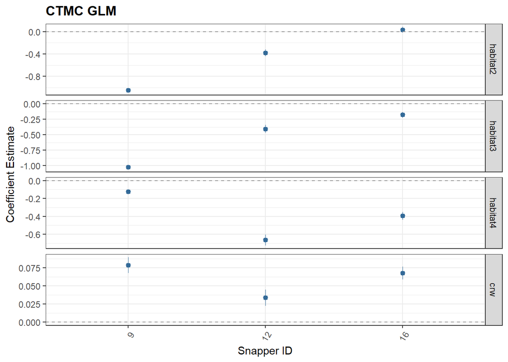

```r
snap_plot <- small_multiple(by_snap) +
  theme_bw() + ylab("Coefficient Estimate") +
  geom_hline(yintercept = 0, colour = "grey60", linetype = 2) +
  ggtitle("CTMC GLM") +
  theme(plot.title = element_text(face = "bold"),
        legend.position = "none",
        axis.text.x = element_text(angle = 60, hjust = 1)) + xlab("Snapper ID")

snap_plot
```

Function used to render html (run in console)

```r
render_report<-function(resolution, title){
  rmarkdown::render(
    here::here("scripts/parameterized_reports/ctmc_parameterized.Rmd"), params=list(
      resolution=resolution,
      title=title
    ),
    output_file = paste0("CTMC 3 snapper example grouped and individual summary for ", resolution, " m^2 grid cell size.html")
    )
}
```